# Spotify Project Arctic Monkeys

Author

Simone Ruijs del Real

## Welcome to my Spotify Project on the Arctic Monkeys

Arctic Monkeys is an English indie rock band founded in 2002. The band comprises four members: Alex Turner (singer and guitar), Jamie Cook (guitar), Nick O’Malley (bass), and Matthew Helders (drums).

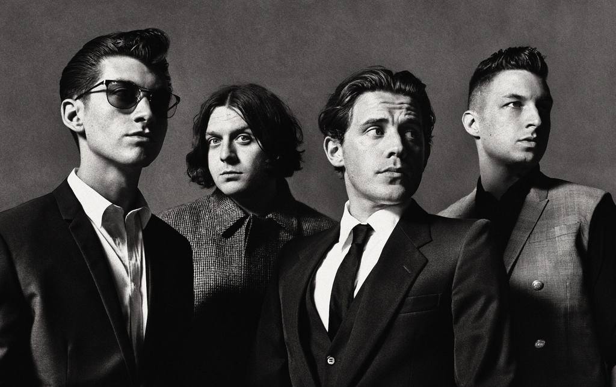

### My favourite song

[505](https://www.youtube.com/watch?v=qU9mHegkTc4)

[video not shown]

### My favourite quote

> “*Maybe I’m too busy being yours to fall for someone new*”

> – Arctic Monkeys

## Cleaning Data

```r
#First we need to load the packages into R to be able to visualise the data#
library(ggplot2)
library(dplyr)
library(readr)
#Then to import the data#
myData <- read.csv("Arctic Monkeys.csv")
```

Sometimes songs are released again under different albums, so to ensure that there are no duplicates, we run the following code. Afterwards, we can see that the observations did not change, so there were fortunately no duplicates.

```r
#Getting rid of the duplicates by keeping all distinct records#
myData <- myData |> distinct(track_name, .keep_all = TRUE)
```

## Presenting Data

### Scatterplot Danceability and Energy of All Albums

I really wanted to present the danceability and energy of all albums and compare them. I really love upbeat songs that I can dance to, so I was curious to see the distribution of their songs.

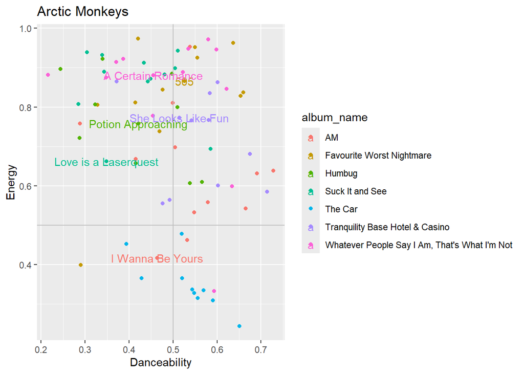

```r
#The scatterplot only works with numerical variables, so to use danceablity and energy, we have to convert them into numerical variables#

myData$danceability <- as.numeric(myData$danceability)
myData$energy  <- as.numeric(myData$energy)

#Then I labeled a few songs on the scatterplot to see how they perform.#
subgroup <- myData |>
  filter(track_name %in% c(
    "I Wanna Be Yours",
    "505",
    "Love is a Laserquest",
    "She Looks Like Fun",
    "A Certain Romance",
    "Potion Approaching"))

#Coding the scatterplot of danceability and energy#
ggplot(myData, aes(x = danceability, y = energy, color = album_name)) +
  geom_point()+
  geom_hline(yintercept = 0.5, color = "grey")+
  geom_vline(xintercept = 0.5, color= "grey")+
  geom_text(data=subgroup, aes(label=track_name))+
  labs(title="Arctic Monkeys", x="Danceability", y="Energy")
```

### Plot Loudness and Energy

Now, I was curious if there was a relationship between the loudness of a song and the energy. During concerts, you can feel the loudness and energy change between tracks. So, let’s take a look at whether loudness and energy have a relationship, or if it is just the atmosphere.

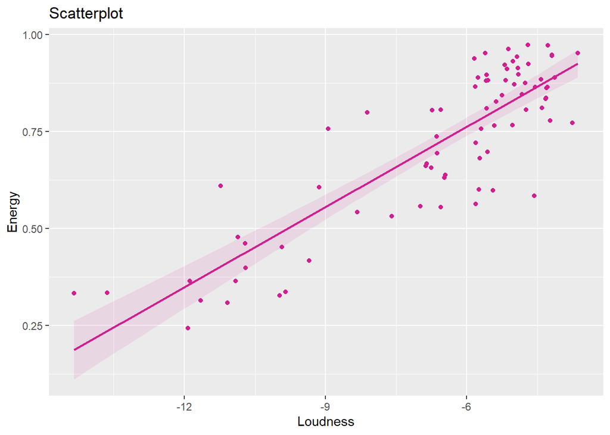

```r
#Coding the scatterplot between loudness and energy
ggplot(myData, aes(x = loudness, y = energy)) +
  geom_point(color = "#D02090") +
  geom_smooth(method = "lm", color = "#D02090", alpha = 0.1, fill = "#D02090")+
  labs(title = "Scatterplot", x = "Loudness", y = "Energy")
```

As you can see in the graph, there is a positive relationship between the loudness of the song and the energy level. The higher the energy, the louder the song is as well.

### Top Danceability

Since I love to dance, I wanted to see which songs are the most danceable. Especially in a top 5 to have it organised clearly. This makes it easier to sort my songs when I want to dance!

```r
#Slicing the 5 most danceable records from the dataframe
myData |> slice_max(danceability, n=5) |> dplyr::select(track_name, album_name, album_release_year, danceability) |> knitr::kable(digits = 2)
```

| track_name | album_name | album_release_year | danceability |
| --- | --- | --- | --- |
| Snap Out Of It | AM | 2013 | 0.73 |
| One Point Perspective | Tranquility Base Hotel & Casino | 2018 | 0.71 |
| Why’d You Only Call Me When You’re High? | AM | 2013 | 0.69 |
| Batphone | Tranquility Base Hotel & Casino | 2018 | 0.68 |
| Knee Socks | AM | 2013 | 0.66 |

As we can see, the top danceable song of Arctic Monkeys is “Snap Out Of It”, which is one of my favourites!

The top danceable song: [Snap Out Of It](https://www.youtube.com/watch?v=1_O_T6Aq85E)

[video not shown]

### 5 Least Danceable Tracks

Since I want to avoid listening to tracks I can’t dance to, I took a little peek into the 5 least danceable tracks among all albums.

```r
#Slicing the 5 least danceable records from the dataframe
myData |> slice_min(danceability, n=5) |> dplyr::select(track_name, album_name, album_release_year, danceability) |> knitr::kable(digits = 2)
```

| track_name | album_name | album_release_year | danceability |
| --- | --- | --- | --- |
| From The Ritz To The Rubble | Whatever People Say I Am, That’s What I’m Not | 2006 | 0.22 |
| Pretty Visitors | Humbug | 2009 | 0.24 |
| Brick By Brick | Suck It and See | 2011 | 0.28 |
| Cornerstone | Humbug | 2009 | 0.29 |
| R U Mine? | AM | 2013 | 0.29 |

## Danceability Comparison

Then, I wanted to compare the danceability between albums to see if the differences are noticeable enough to warrant me skipping them during a dance break.

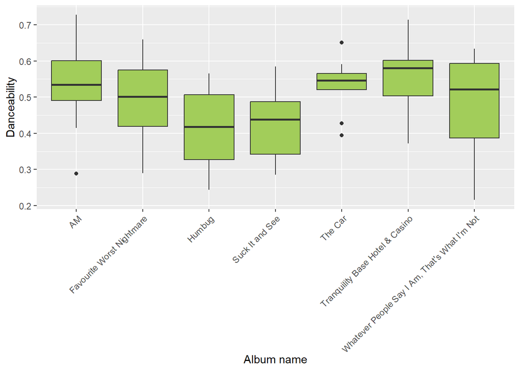

```r
#Plotting Boxplots of all albums on danceability to compare medians

ggplot(myData, aes(x= album_name, y=danceability))+
  geom_boxplot(fill = "#A2CD5A")+
  labs(x="Album name", y="Danceability")+
  theme(axis.text.x = element_text(angle=45, hjust=1))
```

## Result

If you want to dance to Arctic Monkeys, your best bet is to avoid “Humbug”, but instead to opt for AM” and “Tranquility Base Hotel & Casino” for the optimal dancing experience.